# Exploring Prosper Loan Data

## by Haya Aldawood

## Investigation Overview

> *This notebook will explore`prosperLoanData` dataset. This dataset contains 81 varible about differant loans. the following section will contain a walkthrogh for dataset with notes and observations included.*

## Dataset Overview

> The dataset structre is 113,937 rows and 81 column. The dataset contains many variables for each loan posting.

## The distribuation of total investors for each loan

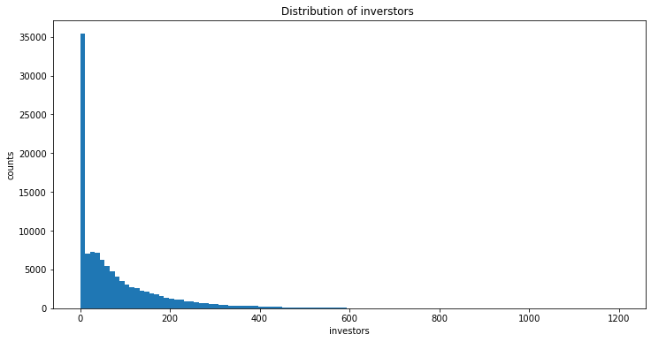

```python
binsize = 11
bins = np.arange(0, df['investors'].max()+binsize, binsize)
plt.figure(figsize=[12, 6])
plt.hist(data = df, x = 'investors', bins = bins)
plt.xlabel('investors')
plt.ylabel('counts')
plt.title("Distribution of inverstors ")
plt.show()
```

## Corelations of different variables

> This objective of this graph in to unfold hidden realtionships bwtween differant variables.I have found out that higher the borrower APR the higher the estimated effective yield, which make sice the higher the interst the brrower will pay the higher the profit the lender will make.

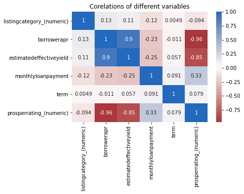

```python
df2=df[['incomerange','listingcategory_(numeric)','borrowerapr','estimatedeffectiveyield' ,'monthlyloanpayment',
        'term', 'prosperrating_(numeric)' ,'incomerange']]
corrMatrix = df2.corr()
sb.heatmap(corrMatrix, annot=True,cmap = 'vlag_r')
plt.title("Corelations of different variables")
plt.show()
```

## Loans That Attracts The Most Investores

This graph objective is view how term and prosper rating effect the attractiveness of a loan. It seems that the term does not effect the likability of attracking a large number of inverstors. However, if a borower has a 7 prosper rating the loan will likely attrack a large number of investors regardless of the term

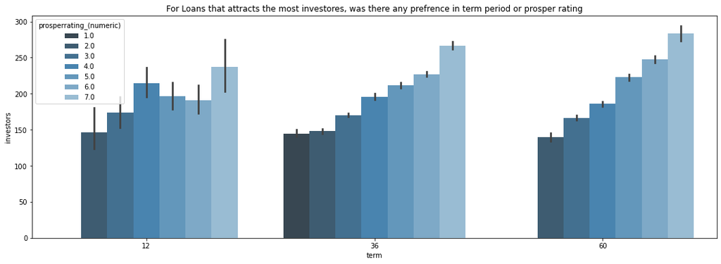

```python
df2= pd.DataFrame(df[df['investors']>=115])
plt.figure(figsize=[18, 6])
sb.barplot(x='term',y='investors',hue='prosperrating_(numeric)',data=df2, palette="Blues_d")
plt.title("For Loans that attracts the most investores, was there any prefrence in term period or prosper rating");
```

```python
!jupyter nbconvert slide_deck_template.ipynb --to slides --post serve --template output_toggle
```

[output not shown]